# L6 - Data Visualization

## Lecture Goals

- Learn how to:
  - Explore data visualy
  - Create layered graphs w/ `ggplot2`
- Readings
  - [R4DS](http://r4ds.had.co.nz/): ch. 3, 7
  - Data Visualization [cheatsheet](https://www.rstudio.com/wp-content/uploads/2015/05/ggplot2-cheatsheet.pdf)

## Data Visualization

- Communicate information *graphically* through plots, charts, maps, etc.
- High-level plot description based on *layered grammar of graphics*
  - Create plots by overlaying *geometric objects* on same coordinates
- R package `ggplot2` implements such grammar for creating plots in R

## Graph Structure

- Basic ingredients
  - **Data**
  - **Aesthetic Mappings**
  - **Geometric Objects** (lines, points, text, etc)
- Extras
  - *Statistics*
  - *Scales*
  - *Facets*
  - Other adjustments (coordinates, annotations, positions)

## Graph Structure

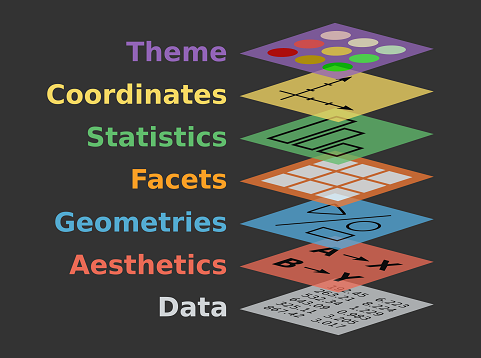

## Aesthetic Mappings

- Geometric objects convey information through their *aesthetics* (i.e. perceived characteristics)
- Data variable(s) can be *mapped* to one or more aesthetics
- Common aesthetic mappings
  - *Location*: x/y coordinates
  - *Appearance*: size, color, shape, etc

## Gapminder Data

- [Gapminder Foundation](https://www.gapminder.org/) is non-profit organization promoting world-wide social, economic and environmental development *through the use of data and statistics*
  - Excellent source of information about state of the world
- `gapminder` package provides excerpt of available [data](https://www.gapminder.org/data/)

```r
library(gapminder); glimpse(gapminder)
## Observations: 1,704
## Variables: 6
## $ country   <fct> Afghanistan, Afghanistan, Afghanistan, Afghanistan, ...
## $ continent <fct> Asia, Asia, Asia, Asia, Asia, Asia, Asia, Asia, Asia...
## $ year      <int> 1952, 1957, 1962, 1967, 1972, 1977, 1982, 1987, 1992...
## $ lifeExp   <dbl> 28.801, 30.332, 31.997, 34.020, 36.088, 38.438, 39.8...
## $ pop       <int> 8425333, 9240934, 10267083, 11537966, 13079460, 1488...
## $ gdpPercap <dbl> 779.4453, 820.8530, 853.1007, 836.1971, 739.9811, 78...
```

## Plotting in `ggplot2`

- Basic syntaxt  
  `ggplot( data, aes(...) ) + geom_*() + ...`

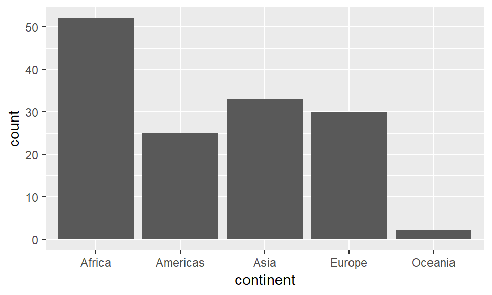

```r
gap07 = gapminder %>% filter( year == "2007")
ggplot(gap07, aes(x = continent)) + geom_bar()
```

## Top 5 Plots

- *Barplot* (`geom_bar`)
- *Histogram* (`geom_histogram`)
- *Boxplot* (`geom_boxplot`)
- *Scatterplot* (`geom_point`)
- *Line plot* (`geom_line`)

| Variable | N/A | discrete | continuous | (time) |
| --- | --- | --- | --- | --- |
| discrete | bar | (bar) | box |  |
| continuous | hist | box | points | line |

## Barplot

- Compare values of *discrete* variable
  - Often used for counts/sums across groups

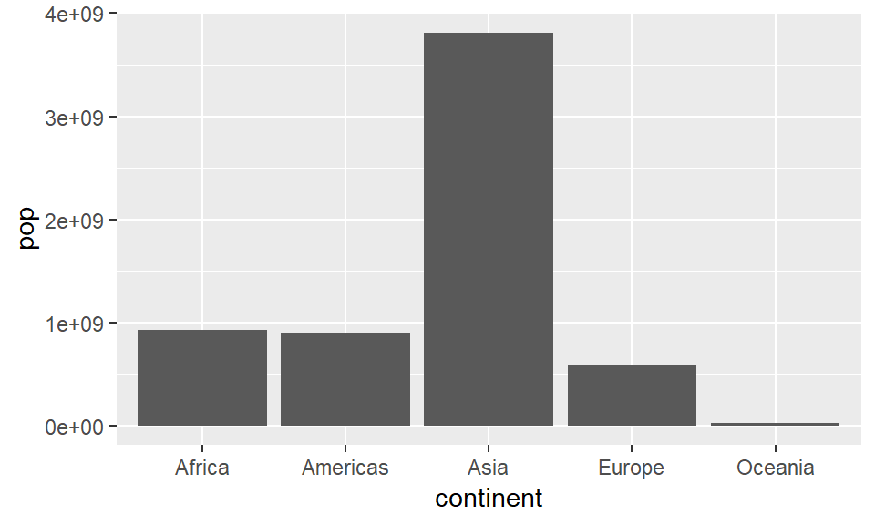

```r
gap07 %>% group_by(continent) %>%
  summarise( pop = sum( as.numeric(pop) ) ) %>%
  ggplot(aes(x = continent, y = pop)) + geom_bar(stat = "identity")
```

## Histogram

- Describe distribution of *continuous* variable

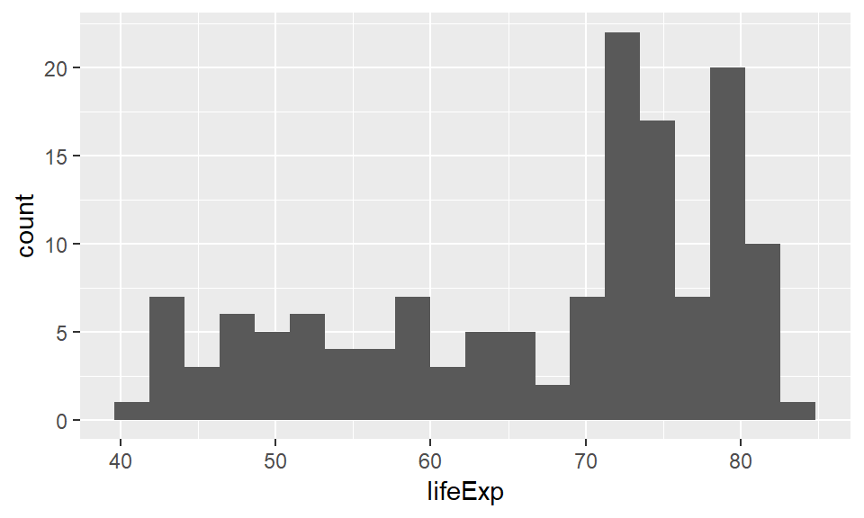

```r
ggplot(gap07, aes(x = lifeExp)) + geom_histogram(bins = 20)
```

## Boxplot

- Compare distributions of continuous variable across levels of discrete variable

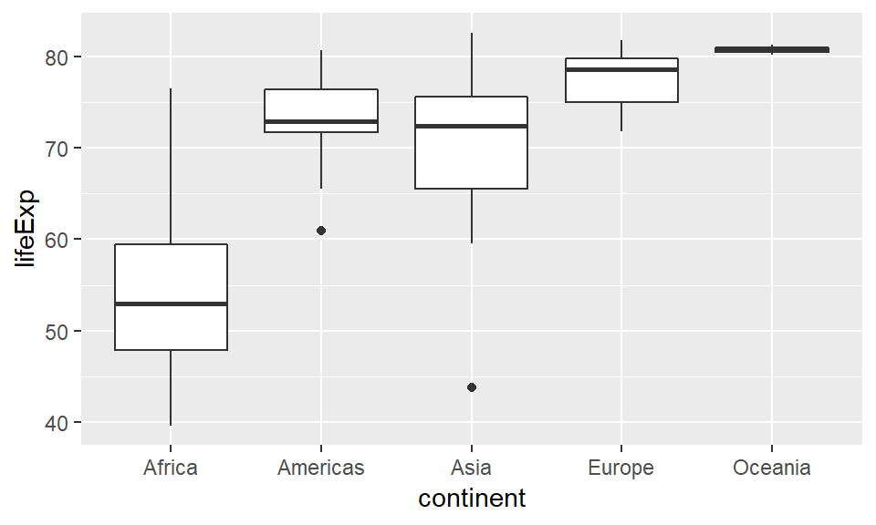

```r
ggplot(gap07, aes(x = continent, y = lifeExp)) + geom_boxplot()
```

## Boxplot

- Describe continuous distribution using *5-point-summary*

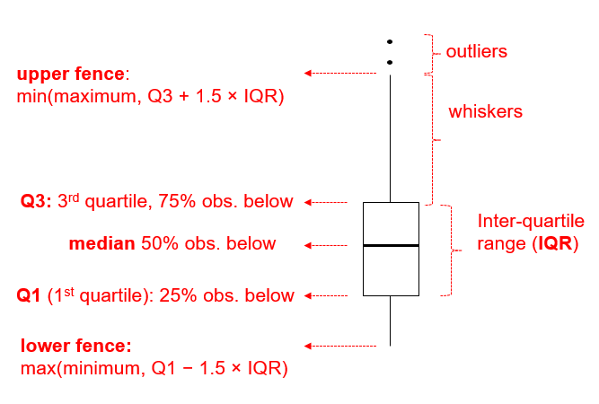

## Scatterplot

- Look at relationship between two continuous variables

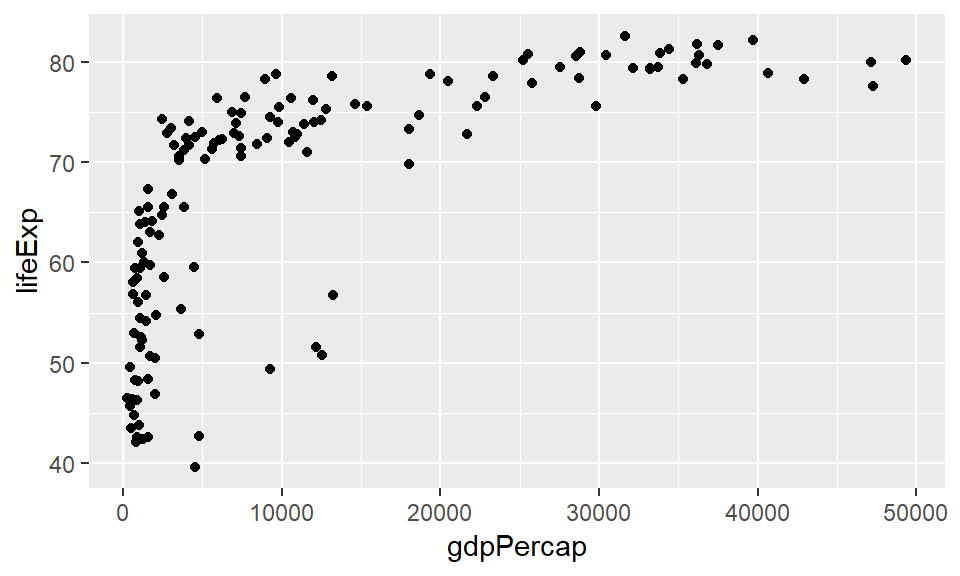

```r
ggplot(gap07, aes(x = gdpPercap, y = lifeExp)) + geom_point()
```

## Line Plot

- For data with *serial structure* (e.g. time series)

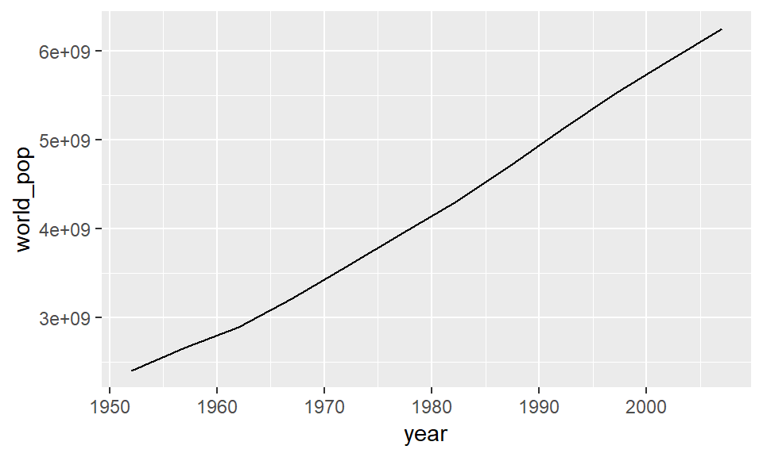

```r
gapminder %>% group_by(year) %>%
  summarise( world_pop = sum(as.numeric(pop))) %>%
  ggplot(aes(x = year, y = world_pop)) + geom_line()
```

## Statistics

- Original data can be *transformed* through `stat` function

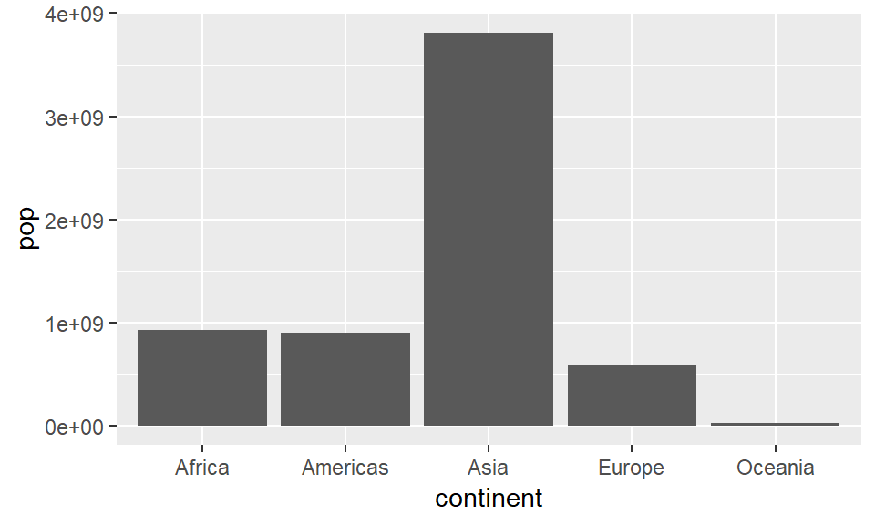

```r
ggplot(gap07, aes(x = continent, y = pop) ) +
  stat_summary(fun.y = "sum", geom = "bar")
```

## Scales

- Scales control *range* of aesthetic mappings.

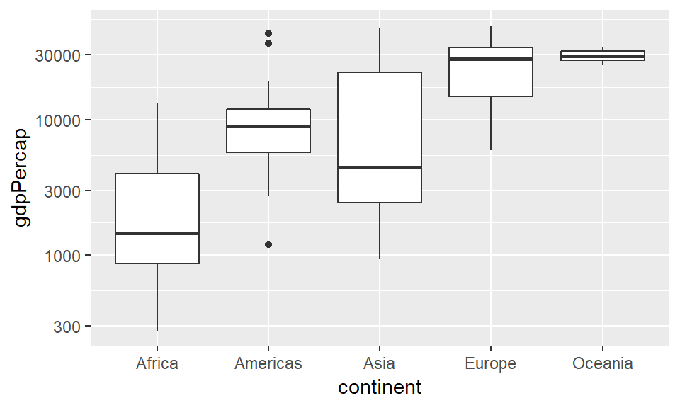

```r
ggplot(gap07, aes(x = continent, y = gdpPercap) ) +
  geom_boxplot() + scale_y_log10()
```

## Faceting

- Create grid of sub-plots, one for each level of a variable

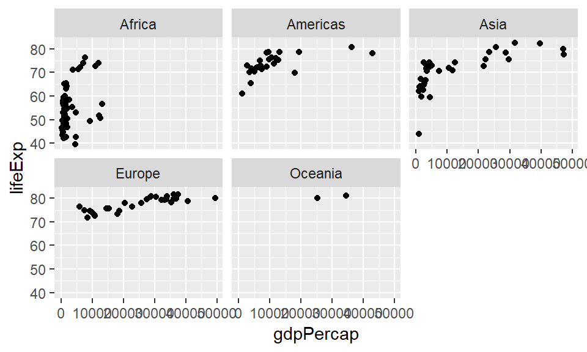

```r
ggplot(gap07, aes(x = gdpPercap, y = lifeExp)) + geom_point() +
  facet_wrap( facets = ~ continent)
```

## Positional Adjustments

- Using *positional adjustments* for bars

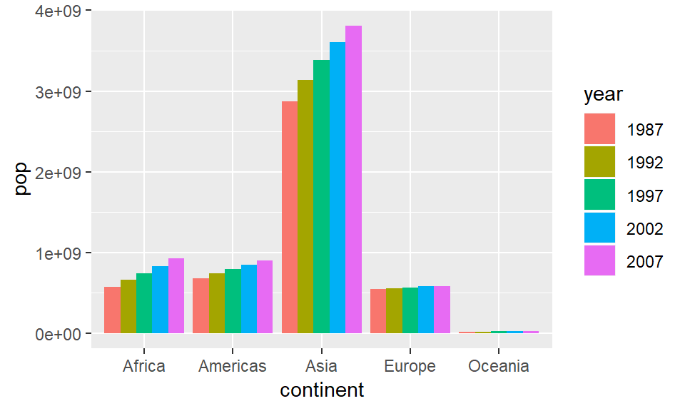

```r
gapminder %>% filter( year > 1985 ) %>%
  mutate( year = as.factor(year), pop = as.numeric(pop) ) %>%
  group_by(year, continent) %>% summarise(pop = sum(pop) ) %>%
  ggplot(aes(x = continent, y = pop, fill = year)) +
  geom_bar(stat = "identity", position = "dodge")
```

## Coordinates

- Manipulate (fix, flip, transform) coordinates

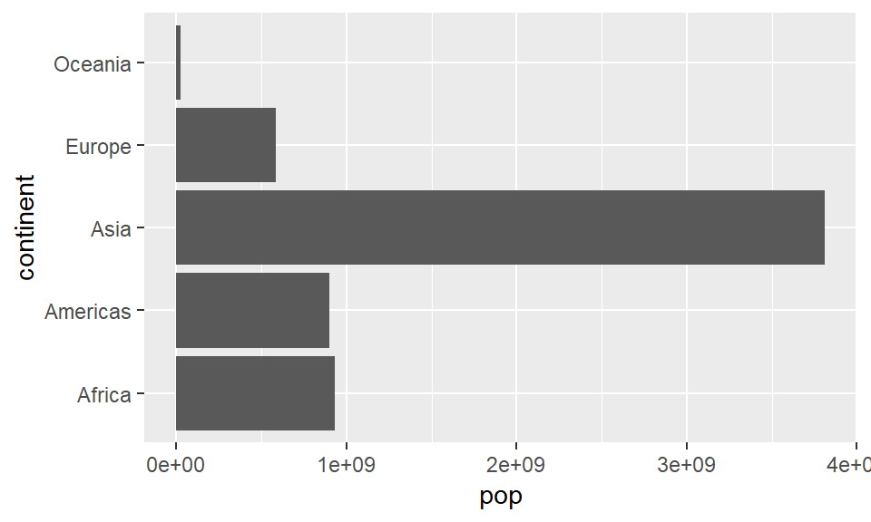

```r
ggplot(gap07, aes(x = continent, y = pop) ) +
  stat_summary(fun.y = "sum", geom = "bar") +
  coord_flip()
```